# Regresión Lineal Múltiple I

Juan Barriola y Sofía Perini

2 de Octubre de 2021

## Planteo del problema

Nuestro objetivo es crear un modelo lineal múltiple para explicar el precio de venta en dólares de las propiedades en Capital Federal reportadas por la empresa [Properati Argentina](https://www.properati.com.ar/).

Vamos a utilizar datos del 2019 para no incorporar comportamientos atípicos ocasionados por la pandemia del COVID-19.

Nuestra idea subyacente de cómo se puede explicar el precio es:

$precio = \beta_0 +\beta_1X_1+\beta_2X_2+...+\epsilon$

```r
library(tidyverse)
library(tidymodels)
library(rsample)
library(ggplot2)
library(GGally)
```

## Levantamos Dataset

Vamos a trabajar con un subconjunto de datos que surgió de un trabajo de limpieza y tratamiento de outliers que se puede consultar en el notebook de Preprocesamiento Dataset Properati, correspondiente a precios de propiedades en Capital Federal, cuyo precio está expresado en dolares (USD), el tipo de propiedad corresponde a Departamento, PH o Casa, y el tipo de operacion sea Venta.

```r
datos_properati <- read.csv("properati_preprocesado.csv")
glimpse(datos_properati)
```

```
Rows: 49,835
Columns: 9
$ id              <chr> "AfdcsqUSelai1ofCAq2B0Q==", "ESzybdH7YU2uIU1/kHtRGw==", "r~
$ l3              <chr> "Velez Sarsfield", "Nuñez", "Almagro", "Almagro", "Almagro~
$ rooms           <int> 3, 1, 1, 1, 1, 1, 1, 1, 1, 1, 1, 1, 1, 1, 1, 3, 1, 1, 2, 1~
$ bathrooms       <int> 2, 1, 1, 1, 1, 1, 1, 1, 1, 1, 1, 1, 1, 1, 1, 2, 1, 1, 1, 1~
$ surface_total   <int> 95, 44, 40, 49, 40, 40, 40, 49, 40, 23, 40, 40, 32, 40, 36~
$ surface_covered <int> 69, 38, 37, 44, 37, 37, 37, 44, 37, 23, 37, 37, 30, 34, 33~
$ price           <dbl> 199900, 147000, 92294, 115000, 77000, 88900, 88798, 110975~
$ property_type   <chr> "Casa", "Departamento", "Departamento", "Departamento", "D~
$ precio_en_miles <int> 200, 147, 92, 115, 77, 89, 89, 111, 93, 69, 99, 97, 125, 1~
```

La limpieza consistió en: eliminar la variable bedrooms por registrar gran presencia de faltantes (40%) y correlación positiva fuerte con la variable rooms (0.97), eliminar los registros con faltantes, descartar registros donde la superficie total resulta inferior a la cubierta, por tratarse probablemente de algún error de carga. Por último, se realizó un tratamiento de los outliers, empleando las técnicas vistas en la clase 3, quedando como resultado un dataset de 49.835 observaciones y 9 columnas, con el que trabajaremos a continuación.

### Seleccionamos variables de interés

En este caso ya están preseleccionadas 9 variables:

- *id*: identificacion.
- *l3*: barrio.
- *rooms*: nro de habitaciones.
- *bathrooms*: nro de baños
- *surface_total*: superficie total en m2
- *surface_covered*: superficie cubierta en m2
- *price*: precio (variable a predecir) en dólares
- *property_type*: tipo de propiedad (Departamento, PH o Casa)
- *precio_en_miles*: variable creada por nosotros para graficar

```r
datos_properati %>%
  head()
```

|  | id | l3 | rooms | bathrooms | surface_total | surface_covered | price | property_type | precio_en_miles |
| --- | --- | --- | --- | --- | --- | --- | --- | --- | --- |
| 1 | AfdcsqUSelai1ofCAq2B0Q== | Velez Sarsfield | 3 | 2 | 95 | 69 | 199900 | Casa | 200 |
| 2 | ESzybdH7YU2uIU1/kHtRGw== | NuÃ±ez | 1 | 1 | 44 | 38 | 147000 | Departamento | 147 |
| 3 | r22OfzZ3kXooSPoE5HMuZQ== | Almagro | 1 | 1 | 40 | 37 | 92294 | Departamento | 92 |
| 4 | atZQXVtyfG7+OiX6gYY3lA== | Almagro | 1 | 1 | 49 | 44 | 115000 | Departamento | 115 |
| 5 | R7IsTtVsxPCiRbIHMaWGxA== | Almagro | 1 | 1 | 40 | 37 | 77000 | Departamento | 77 |
| 6 | Tur/v/qE41UBT83NM/bI7w== | Almagro | 1 | 1 | 40 | 37 | 88900 | Departamento | 89 |

Veamos cómo es la correlación entre las variables numéricas.

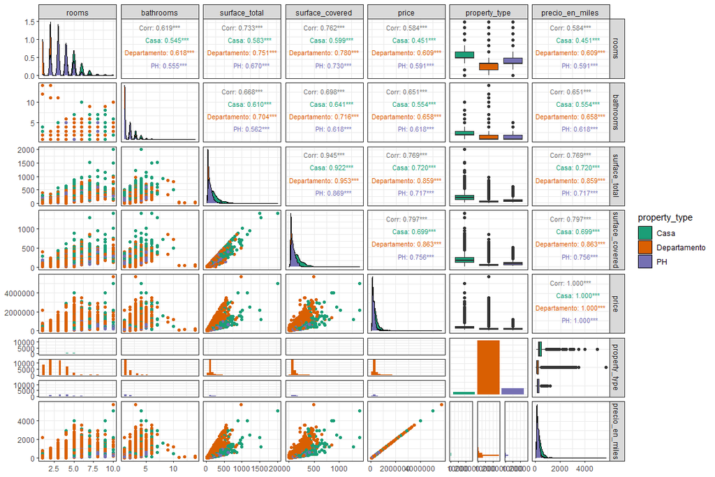

```r
# graficamos con ggpairs coloreando por property type
g <- ggpairs(datos_properati %>% select(-c(id,l3)), aes(color = property_type),
          upper = list(continuous = wrap("cor", size = 3, hjust=0.5)), legend = 25, progress=FALSE) +
  theme(axis.text.x = element_text(angle = 90, hjust = 1), legend.position = "bottom") +
  theme_bw()
# hacemos un loop para cambiar los colores del gráfico
for(i in 1:g$nrow) {
  for(j in 1:g$ncol){
    g[i,j] <- g[i,j] +
      scale_fill_brewer(palette="Dark2") +
      scale_color_brewer(palette="Dark2")
        }
}
g
```

- Las variables superficie cubierta y total presentan una asociación lineal positiva fuerte (0.945).

## Partición del dataset en train y test

En este caso para evaluar los modelos vamos a realizar una partición entre dataset de entrenamiento (75%) y testeo (25%) usando la función `initial_split` del paquete [rsample](https://rsample.tidymodels.org/) de tidymodels.

```r
# fijamos semilla
set.seed(2021)
# Partición Train y Test, indicando proporción
train_test <- initial_split(datos_properati, prop = 0.75)
train_data <- training(train_test)
test_data <- testing(train_test)
# vemos las dimensiones de cada particion
train_data %>%
  dim_desc()
```

```
[1] "[37,376 x 9]"
```

```r
test_data %>%
  dim_desc()
```

```
[1] "[12,459 x 9]"
```

El dataset de test lo utilizaremos en la siguiente clase.

## Modelo Múltiple

El modelo de **regresión lineal múltiple** es un modelo para la variable aleatoria Y cuando se conocen las variables regresoras. Es múltiple ya que vincula una serie de variables predictoras con Y.

El modelo en términos de las variables:

$$Y_i = β_0 + β_1X_{i1} + β_2X_{i2} + · · · + β_{p-1}X_{ip-1} + ε_i$$
donde $β_0$, $β_1$,.., $β_{p−1}$ son parámetros desconocidos, $X_{i1}$, $X_{i2}$, …, $X_{ip-1}$ son los valores de las variables predictoras medidas en el i-ésimo individuo, $Y_i$ es la variable respuesta medida en el i-ésimo individuo (observado) y $ε_i$ es el error para el individuo i-ésimo (no observable).

**Supuestos del modelo lineal**

Se pueden resumir como $ϵ_i$ ~ $N(0,σ^2)$ para todo $1<i<n$, independientes entre sí.

El modelo en términos de la esperanza condicional de Y dadas $X_1$, $X_2$,…, $X_{p-1}$:

$$E(Y|X_1,X_2,...X_{p-1}) = β_0 + β_1X_{i1} + β_2X_{i2} + · · · + β_{p-1}X_{ip-1}$$

El modelo se denomina *lineal* puesto que la esperanza de Y condicional a las X’s depende linealmente de las covariables $X_1$, $X_2$,…, $X_{p-1}$.

### Estimación de los Parámetros (ajuste del modelo)

Se quiere ajustar un modelo para el precio de las propiedades en función de 2 variables:

$precio = \beta_0 + \beta_1x_{i1} + \beta_2x_{i2} + \epsilon_i$

Veamos cómo se interpretan los ajustes para los distintos tipos de predictores.

### *1) Predictores numéricos*

Armemos un modelo para predecir el precio en función de la superficie cubierta y la cantidad de habitaciones. Veamos los resultados del modelo empleando la función tidy().

```r
# ajustamos modelo lineal multiple
modelo_sc_r <- lm(price ~ surface_covered + rooms, data = train_data)
# Resumen del modelo
tidy_sc_r <- tidy(modelo_sc_r, conf.int = TRUE)
tidy_sc_r
```

| term | estimate | std.error | statistic | p.value | conf.low | conf.high |
| --- | --- | --- | --- | --- | --- | --- |
| (Intercept) | 21638.834 | 1648.51562 | 13.12625 | 2.845365e-39 | 18407.699 | 24869.970 |
| surface_covered | 3183.151 | 17.77305 | 179.09989 | 0.000000e+00 | 3148.315 | 3217.986 |
| rooms | -10942.468 | 810.33680 | -13.50360 | 1.863188e-41 | -12530.750 | -9354.186 |

#### Significado de los coeficientes estimados

- El valor de $\hat{\beta_0}$ (ordenada al origen) es 2.1639^{4} dólares, lo que corresponde al precio **esperado** de una propiedad con 0 habitaciones y sin superficie. Lo cual, este caso carecería de sentido ya que las propiedades deberían tener superficie y al menos alguna habitación/ambiente.
- El coeficiente estimado de $\hat{\beta_{surface\_covered}}$ (superficie cubierta) es de 3183 dólares, lo que indica que si mantenemos el número de habitaciones constante, cada incremento de un m2 adicional de superficie corresponde a un aumento de 3183 dólares, **en promedio** en el precio de la propiedad. O lo que es igual, dadas dos propiedades con la misma cantidad de habitaciones pero teniendo una un m2 más de superficie que la otra, el precio **esperado** para la de mayor superficie será 3183 dólares más alto que la de menor superficie.

¿Cómo se interpretaría el coeficiente estimado del número de habitaciones?

### *2) Predictores Categóricos*

Armemos un modelo para predecir el precio de la propiedad en función de la superficie cubierta y el tipo de propiedad (*property_type*), que es categórica con tres niveles (Casa, Departamento o PH). Para ello, vamos a analizar primero el comportamiento de la variable que queremos predecir para cada tipo de propiedad a través de un boxplot.

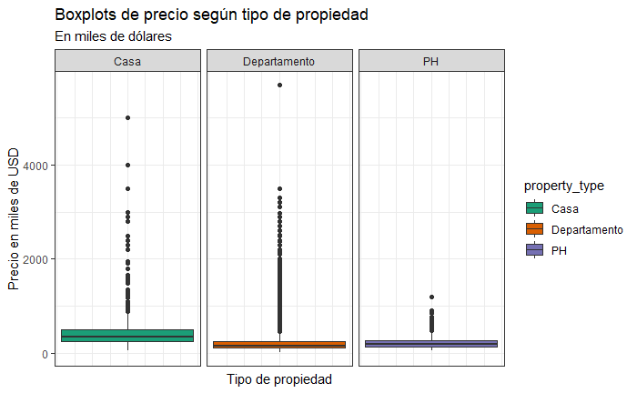

```r
# armamos boxplots paralelos de precio segun el tipo de propiedad (casa, dpto o ph)
ggplot(data = train_data, aes(y = precio_en_miles, group = property_type, fill = property_type)) +
         geom_boxplot() +
         scale_fill_brewer(palette="Dark2") +
  theme_bw() +
  theme(axis.text.x=element_blank(),
        axis.ticks.x=element_blank()) +
         labs(title = "Boxplots de precio según tipo de propiedad", subtitle = "En miles de dólares") +
  labs(y = "Precio en miles de USD") +
  labs(x = "Tipo de propiedad") +
  facet_wrap(~property_type)
```

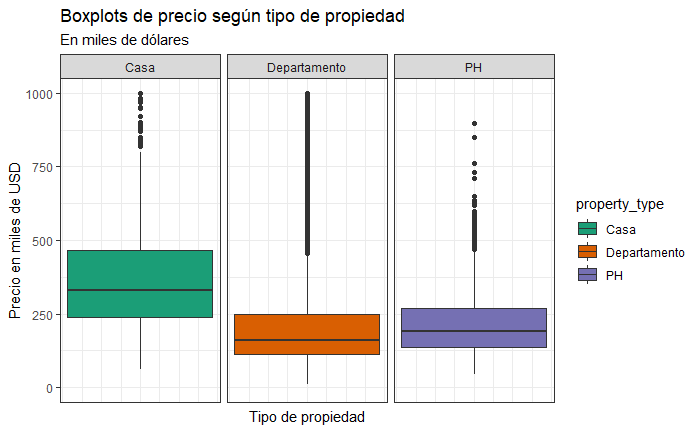

```r
# Acotando la escala del grafico para visualizar mejor el rango intercuartil
ggplot(data = train_data, aes(y = precio_en_miles, group = property_type, fill = property_type)) +
         geom_boxplot() +
         scale_fill_brewer(palette="Dark2") +
  theme_bw() +
  scale_y_continuous(limits = c(0, 1000)) +
  theme(axis.text.x=element_blank(),
        axis.ticks.x=element_blank()) +
         labs(title = "Boxplots de precio según tipo de propiedad", subtitle = "En miles de dólares") +
  labs(y = "Precio en miles de USD") +
  labs(x = "Tipo de propiedad") +
  facet_wrap(~property_type)
```

Analizando la variable de *tipo de propiedad* en función de la variable a predecir, se observa una diferencia en los precios según el tipo de propiedad. En particular, las casas presentan mayores precios y a su vez, mayor variabilidad que los departamentos y PHs.

Veamos qué ocurre cuando **ajustamos el modelo**:

```r
# ajustamos el modelo de superficie y tipo de propiedad
modelo_sc_pt <- lm(price ~ surface_covered + property_type, data = train_data)
tidy_sc_pt <- tidy(modelo_sc_pt, conf.int = TRUE)
tidy_sc_pt
```

| term | estimate | std.error | statistic | p.value | conf.low | conf.high |
| --- | --- | --- | --- | --- | --- | --- |
| (Intercept) | -219751.606 | 4257.70914 | -51.61264 | 0.000000e+00 | -228096.833 | -211406.379 |
| surface_covered | 3309.918 | 11.95287 | 276.91410 | 0.000000e+00 | 3286.491 | 3333.346 |
| property_typeDepartamento | 218713.785 | 3919.80459 | 55.79711 | 0.000000e+00 | 211030.860 | 226396.709 |
| property_typePH | 119276.889 | 4297.09732 | 27.75755 | 7.174654e-168 | 110854.460 | 127699.318 |

#### Significado de los coeficientes estimados

¿Cómo cambia la **interpretación** de los coeficientes para la variable categórica?

El modelo de regresión lineal en este caso consiste simplemente en expresar la media del nivel de precios en cada población (de casas, departamentos o PHs) mediante tres coeficientes distintos, donde:

- $\beta_0$ (categoría basal de variable categórica) es la media del precio para las Casas sin superficie. En este modelo es de -2.19752^{5} dólares, lo que carece de sentido económico ya que las casas deberían tener alguna superficie y no podrían tener un precio negativo.
- $\beta_0 + \beta_{property\_typeDepartamento}$ es la media del precio para los departamentos, dada la superficie. Por lo tanto, $\beta_{property\_typeDepartamento}$ es la diferencia en los **niveles medios** de precios de los departamentos respecto de las casas (categoría basal).Es decir, $\beta_{property\_typeDepartamento}$ (2.18714^{5}) indica cuánto más alta es la función de respuesta (precio) para los departamentos respecto de las casas (categoría basal), dada la superficie.
- Vemos que el nivel medio del precio es una función lineal de la superficie de la propiedad, con una misma pendiente $\beta_{surface_total}$ 3310 para casas, departamentos y PHs.

¿Cómo se interpretaría entonces $\beta_{property\_typePH}$? ¿Y $\beta_0 + \beta_{property\_typePH}$?

#### Grafiquemos la regresión para las tres poblaciones

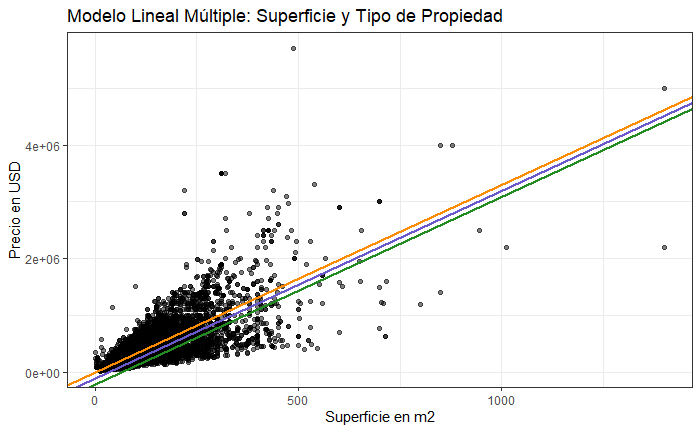

### *Predictores Cualitativos con muchas clases*

La variable barrios (l3) tiene 57 niveles distintos. Veamos a través de boxplots paralelos cómo se comportan.

```r
length(unique(datos_properati$l3)) # 57 barrios
```

```
[1] 57
```

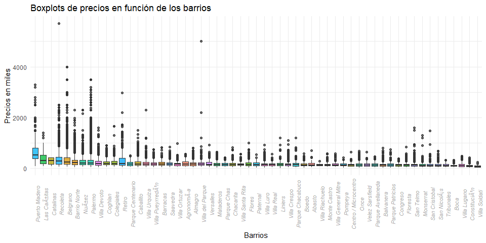

```r
# armo scatterplot de precios en miles en función de superficie total
ggplot( datos_properati, aes(x = fct_reorder(l3, price, .desc = T), y = price/1000)) +
  geom_boxplot(alpha = 0.75, aes(fill = l3)) +
  theme_minimal() +
  theme(legend.position = 'none')+
  labs(y = "Precios en miles", x = "Barrios")  +
  ggtitle("Boxplots de precios en función de los barrios")+
  theme (axis.text.x = element_text(face="italic", colour="dark grey", size = 8, angle = 90))
```

Dado que la presencia de outliers univariados dificulta la observación, realizamos nuevamente el gráfico quitando estas observaciones atípicas.

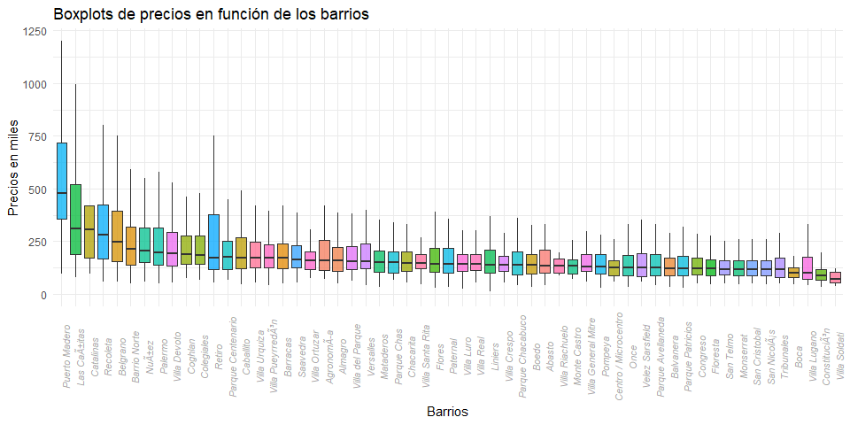

```r
# armamos scatterplot de precios en miles en función de superficie total
ggplot(datos_properati, aes(x = fct_reorder(l3, price, .desc = T), y = price/1000)) +
  geom_boxplot(outlier.shape = NA, alpha = 0.75, aes(fill = l3)) +
  theme_minimal() +
  theme(legend.position = 'none')+
  labs(y = "Precios en miles", x = "Barrios")  +
  scale_y_continuous(limits = c(0, 1200)) +
  ggtitle("Boxplots de precios en función de los barrios")+
  theme (axis.text.x = element_text(face="italic", colour="dark grey", size = 8, angle = 90))
```

En los boxplots paralelos de precios por barrios se puede ver que entre los barrios que presentan mayores precios se ubican: Puerto Madero,Las Cañitas, Catalinas, Recoleta y Belgrano, mientras que Villa Soldati, Constitución, Villa lugano y la Boca presentan los menores precios de propiedades.

```r
# ajustamos el modelo
modelo_sc_l3 <- lm(price ~ surface_covered + l3, data = train_data)
tidy_sc_l3 <- tidy(modelo_sc_l3, conf.int = TRUE)
tidy_sc_l3
```

| term | estimate | std.error | statistic | p.value | conf.low | conf.high |
| --- | --- | --- | --- | --- | --- | --- |
| (Intercept) | -4426.468 | 8445.54659 | -0.5241186 | 6.001992e-01 | -20979.972 | 12127.036 |
| surface_covered | 2885.829 | 10.59769 | 272.3073389 | 0.000000e+00 | 2865.057 | 2906.601 |
| l3AgronomÃa | -39158.800 | 17101.00539 | -2.2898537 | 2.203536e-02 | -72677.241 | -5640.358 |
| l3Almagro | -15372.007 | 8726.38578 | -1.7615548 | 7.815273e-02 | -32475.963 | 1731.950 |
| l3Balvanera | -40959.982 | 9182.48357 | -4.4606649 | 8.194414e-06 | -58957.903 | -22962.061 |
| l3Barracas | -40132.329 | 10789.21252 | -3.7196717 | 1.997740e-04 | -61279.483 | -18985.175 |
| l3Barrio Norte | 46237.492 | 8967.43043 | 5.1561585 | 2.533523e-07 | 28661.081 | 63813.903 |
| l3Belgrano | 86759.749 | 8695.82484 | 9.9771730 | 2.052709e-23 | 69715.693 | 103803.805 |
| l3Boca | -61420.228 | 13775.22995 | -4.4587443 | 8.268132e-06 | -88420.058 | -34420.397 |
| l3Boedo | -43142.274 | 10567.37103 | -4.0825929 | 4.462870e-05 | -63854.612 | -22429.936 |

[output cut: 48 more lines]

R cuando efectúa la regresión calcula automáticamente las variables indicadoras (dummies) para las covariables categóricas, en general según orden alfabético. Podemos chequear el orden para verificar cuál es la categoría basal. En este caso, la categoría de referencia corresponde al barrio de *Abasto*.

#### Significado de los coeficientes estimados

¿Qué significan los coeficientes de esta variable categórica?

- Este modelo propone ajustar una recta distinta para el precio **medio** de cada población definida por el barrio, todas con igual pendiente (definida por la superficie), y 57 ordenadas al origen diferentes, una por cada barrio.
- Por ejemplo, eligiendo un barrio de precios altos, vemos que $\beta_{Belgrano}$ indica cuánto se incrementa el precio medio de las propiedades para aquellos inmuebles ubicados en Belgrano respecto de aquellos ubicados en Abasto (categoría basal), dada la superficie.
- Analizando un barrio de precios bajos, $\beta_{Boca}$ indica cuánto se reduce el precio medio de las propiedades ubicadas en la Boca respecto de aquellas ubicadas en Abasto (categoría basal), dada la superficie.

## Inferencia de los $β_k$ (test de significatividad individual)

#### Test para las $β_k$

Para evaluar la significativdad individual de cada una de las variables se analiza el test t que busca probar si el coeficiente de regresión correspondiente a dicha variable es distinto de 0 (figura en la tabla resumen de resultados de la regresión).

Es decir, busca probar:

- $H_0: \beta_k = 0$
- $H_1: \beta_k ≠ 0$.

**Modelo Superficie y Habitaciones**

```r
options("scipen"=1)
tidy_sc_r %>%
  select(term, statistic, p.value, conf.low, conf.high)
```

| term | statistic | p.value | conf.low | conf.high |
| --- | --- | --- | --- | --- |
| (Intercept) | 13.12625 | 2.845365e-39 | 18407.699 | 24869.970 |
| surface_covered | 179.09989 | 0.000000e+00 | 3148.315 | 3217.986 |
| rooms | -13.50360 | 1.863188e-41 | -12530.750 | -9354.186 |

**Modelo Superficie y Tipo de Propiedad**

```r
tidy_sc_pt %>%
  select(term, statistic, p.value, conf.low, conf.high)
```

| term | statistic | p.value | conf.low | conf.high |
| --- | --- | --- | --- | --- |
| (Intercept) | -51.61264 | 0.000000e+00 | -228096.833 | -211406.379 |
| surface_covered | 276.91410 | 0.000000e+00 | 3286.491 | 3333.346 |
| property_typeDepartamento | 55.79711 | 0.000000e+00 | 211030.860 | 226396.709 |
| property_typePH | 27.75755 | 7.174654e-168 | 110854.460 | 127699.318 |

- En este caso también se observa que todas las variables resultan estadísticamente significativas para explicar al precio de las propiedades (p-valores < 0.05).
- Además del resultado del test, podemos corroborar que los intervalos de confianza del 95% para los coeficientes estimados no contienen al 0 en ninguno de los casos.

##### ¿Cómo se interpreta la significatividad de las variables categóricas?

- En el caso de la variable tipo de propiedad, este test permite chequear si los valores medios del precio son los mismos para los departamentos o PHs respecto de las casas (categoría basal).

**Modelo Superficie Total y Barrios**

```r
tidy_sc_l3 %>%
  select(term, statistic, p.value, conf.low, conf.high) %>%
  arrange(p.value)
```

| term | statistic | p.value | conf.low | conf.high |
| --- | --- | --- | --- | --- |
| surface_covered | 272.3073389 | 0.000000e+00 | 2865.057 | 2906.601 |
| l3Puerto Madero | 31.1468958 | 2.782515e-210 | 304532.681 | 345434.119 |
| l3Villa Lugano | -11.5829594 | 5.680873e-31 | -165936.831 | -117905.955 |
| l3Belgrano | 9.9771730 | 2.052709e-23 | 69715.693 | 103803.805 |
| l3Las Cañitas | 9.8334995 | 8.608484e-23 | 93498.415 | 140049.536 |
| l3Palermo | 9.0167623 | 2.027079e-19 | 60517.847 | 94135.846 |
| l3Recoleta | 8.7593289 | 2.045148e-18 | 60030.286 | 94640.022 |
| l3Mataderos | -7.6244994 | 2.507805e-14 | -104067.948 | -61504.336 |
| l3Pompeya | -7.0180047 | 2.288925e-12 | -142370.431 | -80207.597 |
| l3Nuñez | 6.1118838 | 9.943517e-10 | 38444.391 | 74742.404 |

[output cut: 48 more lines]

- En este modelo se observa que mientras la variable superficie resulta estadísticamente significativa para explicar al precio (p-valores < 0.05), las categorías de barrios no. Hay algunos que resultan significativos y otros no.
- Esto mismo se observa a través de los intervalos de confianza del 95% donde algunos contienen al 0 (por ej. Caballito) y otros no (por ej. Puerto Madero).

##### ¿Cómo se interpreta la significatividad de las variables indicadoras?

- Este test permite chequear si los valores medios del precio de propiedades son los mismos en los distintos barrios respecto de la categoría basal. Cabe destacar, que estos p-valores son válidos para las comparaciones individuales respecto de la categoría basal pero no abarcan todas las comparaciones de a pares.
- Es decir, que los niveles medios de precio de inmuebles en los distintos barrios en algunos casos difieren de los niveles medios del Abasto (basal) y en otros no.
- Si queremos evaluar las variables *property_type* o *l3* en su conjunto, debemos recurrir a un test F.

## Test F (para evaluar significatividad conjunta de la variable categórica para explicar a la respuesta)

El test conjunto F (y su correspondiente p-valor) permite medir la significatividad conjunta de una variable categórica para explicar la respuesta.

Se construye para testear si todos los parámetros asociados a las categorías de una variable categórica son cero, es decir, para probar las hipótesis:

- $H_0: β_q = β_{q+1} = · · · = β_{p−1} = 0$
- $H_1:$ al menos uno de los $β_k$ (con $k entre q y p−1$) est tal que $β_k \neq 0$.

En nuestro caso queremos testear si la variable categórica tipo de propiedad (o barrios) es significativa para explicar el nivel de precios de venta de inmuebles cuando en el modelo tenemos a la superficie cubierta como explicativa.

Dichos tests F se obtienen para cada variable de la tabla de ANOVA del modelo. Veamos qué ocurre en este caso.

```r
# Modelo Superficie Total y Tipo de Propiedad
tidy(anova(modelo_sc_pt))
```

| term | df | sumsq | meansq | statistic | p.value |
| --- | --- | --- | --- | --- | --- |
| surface_covered | 1 | 1.230270e+15 | 1.230270e+15 | 75708.008 | 0 |
| property_type | 2 | 7.402586e+13 | 3.701293e+13 | 2277.691 | 0 |
| Residuals | 37372 | 6.073025e+14 | 1.625020e+10 | NA | NA |

La tabla de ANOVA muestra que, según el resultado del test F, la variable *property_type* en su conjunto resulta estadísticamente significativa para explicar al precio (p-valor < 0.05).

```r
# Modelo Superficie Total y Barrios
tidy(anova(modelo_sc_l3))
```

| term | df | sumsq | meansq | statistic | p.value |
| --- | --- | --- | --- | --- | --- |
| surface_covered | 1 | 1.230270e+15 | 1.230270e+15 | 84183.9861 | 0 |
| l3 | 56 | 1.359607e+14 | 2.427869e+12 | 166.1323 | 0 |
| Residuals | 37318 | 5.453677e+14 | 1.461407e+10 | NA | NA |

La tabla de ANOVA muestra que, según el resultado del test F, la variable *l3* en su conjunto resulta estadísticamente significativa para explicar al precio (p-valor < 0.05). Es decir, que pese a que algunas categorías en su comparación individual con la categoría basal sean poco significativas, la variable en su conjunto sí resulta significativa para el modelo.

Si este test no resultara significativo, suele descartarse la variable categórica de entre las covariables de interés, y se la excluye del modelo. Por el contrario, si este test resulta estadísticamente significativo, entonces suelen mirarse con más detalle cuáles de las comparaciones entre grupos son estadísticamente significativas, para proporcionar un mejor análisis de los datos.

Otra alternativa sería generar una nueva variable con menor número de variables categóricas que sean significativas, sin perder capacidad explicativa. Por ejemplo, se podría armar una nueva variable que agrupe los barrios.

### Generación de nueva varible `tipo_barrio`

- Se crea una nueva variable `tipo_barrio` que clasifica a los barrios según el precio por metro cuadrado promedio de las propiedades en ellos, de acuerdo a precios altos, medios y bajos.
- Para ello, primero se genera una nueva variable de precios por metro cuadrado `pxm2` para poder generar una clasificación del barrio en base a una decisión de negocio (lo que vale en promedio el metro cuadrado en cada barrio).

```r
# Creamos una nueva variable  de precios por metro cuadrado
train_data = train_data %>%
  mutate(pxm2 = round(price/surface_total,0))
# Armamos un dataframe que muestre los promedios de pxm2 en cada barrio
AVG_pxm2_l3 = train_data %>%
  group_by(l3) %>%
  summarise(AVG_pxm2_l3 = mean(pxm2))
AVG_pxm2_l3
```

| l3 | AVG_pxm2_l3 |
| --- | --- |
| Abasto | 2594.864 |
| AgronomÃa | 2072.136 |
| Almagro | 2463.193 |
| Balvanera | 2124.269 |
| Barracas | 2187.227 |
| Barrio Norte | 3171.869 |
| Belgrano | 3318.706 |
| Boca | 1762.789 |
| Boedo | 2098.045 |
| Caballito | 2595.785 |

[output cut: 47 more lines]

Observemos la distribución de los precios promedio por m2.

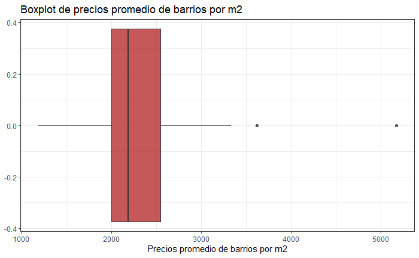

```r
# boxplot de precios por metro cuadrado
ggplot(data = AVG_pxm2_l3, aes(x = AVG_pxm2_l3)) +
  geom_boxplot(alpha = 0.75, fill="firebrick") +
  labs(title = "Boxplot de precios promedio de barrios por m2") +
  labs(x = "Precios promedio de barrios por m2") +
  theme_bw()
```

Aplicaremos el siguiente criterio para agrupar los barrios en:

- **precio_bajo**: barrios cuyo precio promedio por m2 sea menor al Q1
- **precio_medio**: barrios cuyo precio promedio se encuentre en el RI
- **precio_alto**: barrios cuyo precio promedio por m2 sea mayor al Q3

```r
# armamos nueva variable siguiendo tales criterios
AVG_pxm2_l3 = AVG_pxm2_l3 %>%
  mutate(tipo_barrio = case_when(
    AVG_pxm2_l3 < quantile(AVG_pxm2_l3)[2] ~ "precio_bajo",
    AVG_pxm2_l3 >= quantile(AVG_pxm2_l3)[2] & AVG_pxm2_l3 < quantile(AVG_pxm2_l3)[4] ~ "precio_medio",
    TRUE ~ "precio_alto"
                                 )
         )
write.csv(AVG_pxm2_l3, 'AVG_pxm2_l3.csv')
# write_csv(AVG_pxm2_l3, 'AVG_pxm2_l3_.csv')
# unimos esta clasificación al dataset original
train_data = train_data %>% left_join(AVG_pxm2_l3, by = 'l3')
head(train_data)
```

|  | id | l3 | rooms | bathrooms | surface_total | surface_covered | price | property_type | precio_en_miles | pxm2 | AVG_pxm2_l3 | tipo_barrio |
| --- | --- | --- | --- | --- | --- | --- | --- | --- | --- | --- | --- | --- |
| 1 | w21mvtkWs2blwkvX34sJzg== | Parque Chacabuco | 6 | 1 | 330 | 160 | 258000 | Casa | 258 | 782 | 1958.554 | precio_bajo |
| 2 | tFU9QzBDMYaxi/htTMvR4Q== | Balvanera | 6 | 4 | 189 | 189 | 315000 | Departamento | 315 | 1667 | 2124.269 | precio_medio |
| 3 | I+CcZF7vd+ItaaPf9yurjg== | Barrio Norte | 6 | 2 | 161 | 161 | 470000 | Departamento | 470 | 2919 | 3171.869 | precio_alto |
| 4 | xb4W76FwwHZK2EMhOoI90A== | Almagro | 4 | 1 | 89 | 79 | 189000 | Departamento | 189 | 2124 | 2463.193 | precio_medio |
| 5 | 3ttstn4vEm2eMniOCTYppQ== | Villa Urquiza | 2 | 1 | 37 | 37 | 115000 | Departamento | 115 | 3108 | 2763.688 | precio_alto |
| 6 | uwcpQgopCiuZ24d7VBsJ4g== | San Cristobal | 1 | 1 | 38 | 34 | 93578 | Departamento | 94 | 2463 | 2045.715 | precio_medio |

Ajustamos el modelo con la nueva variable tipo_barrio en vez de l3.

```r
# ajustamos el modelo
modelo_sc_tb <- lm(price ~ surface_covered + tipo_barrio, data = train_data)
tidy_sc_tb <- tidy(modelo_sc_tb, conf.int = TRUE)
tidy_sc_tb
```

| term | estimate | std.error | statistic | p.value | conf.low | conf.high |
| --- | --- | --- | --- | --- | --- | --- |
| (Intercept) | 50886.694 | 1248.3226 | 40.76406 | 0 | 48439.947 | 53333.441 |
| surface_covered | 2937.961 | 10.8928 | 269.71594 | 0 | 2916.611 | 2959.311 |
| tipo_barrioprecio_bajo | -130070.795 | 2667.6639 | -48.75831 | 0 | -135299.489 | -124842.101 |
| tipo_barrioprecio_medio | -84906.338 | 1390.0732 | -61.08048 | 0 | -87630.920 | -82181.757 |

¿Qué pasa ahora con la significatividad de los predictores?

## Test F (test de significatividad global)

Se construye para testear las hipótesis:

- $H_0: β_1 = β_2 = · · · = β_{p−1} = 0$
- $H_1:$ no todos los $β_k$ ($k = 1, 2,..., p−1$) son iguales a 0.

Observemos que $H_0$ dice que no hay vínculo entre la variable respuesta y las regresoras. En cambio, $H_1$ dice que al menos una de las variables regresoras sirve para predecir a Y.

Los resultados de este test se pueden observar haciendo un `summary()` del modelo o `glance()`.

```r
glance(modelo_sc_pt)
```

| r.squared | adj.r.squared | sigma | statistic | p.value | df | logLik | AIC | BIC | deviance | df.residual | nobs |
| --- | --- | --- | --- | --- | --- | --- | --- | --- | --- | --- | --- |
| 0.6823065 | 0.682281 | 127476.3 | 26754.46 | 0 | 3 | -492412.8 | 984835.5 | 984878.1 | 6.073025e+14 | 37372 | 37376 |

```r
summary(modelo_sc_pt)
```

```
Call:
lm(formula = price ~ surface_covered + property_type, data = train_data)

Residuals:
     Min       1Q   Median       3Q      Max
-2214134   -42066    -9599    27641  4082488

Coefficients:
                            Estimate Std. Error t value Pr(>|t|)
(Intercept)               -219751.61    4257.71  -51.61   <2e-16 ***
surface_covered              3309.92      11.95  276.91   <2e-16 ***
property_typeDepartamento  218713.78    3919.80   55.80   <2e-16 ***
property_typePH            119276.89    4297.10   27.76   <2e-16 ***
---
Signif. codes:  0 ‘***’ 0.001 ‘**’ 0.01 ‘*’ 0.05 ‘.’ 0.1 ‘ ’ 1

Residual standard error: 127500 on 37372 degrees of freedom
Multiple R-squared:  0.6823,    Adjusted R-squared:  0.6823
F-statistic: 2.675e+04 on 3 and 37372 DF,  p-value: < 2.2e-16
```